# Unsupervised machine learning

Pablo Barbera

June 28, 2017

## Exploring large-scale text datasets

In this session we will discuss how to compute descriptive statistics of text datasets. We’ll be working with the dataset of inaugural speeches of U.S. Presidents.

```r
# reading data and computing additional variables
library(readtext)
library(quanteda)
inaug <- readtext(file='../data/inaugural/*.txt')
inaug$year <- stringr::str_sub(inaug$doc_id, 1, 4)

# creating corpus object
inaug <- corpus(inaug)
```

### Summary statistics

The simplest of the summary statistics we can compute can be obtained through the `summary()` method:

```r
summary(inaug)
```

```
## Corpus consisting of 58 documents.
##
##                 Text Types Tokens Sentences year
##  1789-Washington.txt   625   1538        23 1789
##  1793-Washington.txt    96    147         4 1793
##       1797-Adams.txt   826   2578        37 1797
##   1801-Jefferson.txt   717   1927        41 1801
##   1805-Jefferson.txt   804   2381        45 1805
##     1809-Madison.txt   535   1263        21 1809
##     1813-Madison.txt   541   1302        33 1813
##      1817-Monroe.txt  1040   3680       121 1817
##      1821-Monroe.txt  1259   4886       129 1821
##       1825-Adams.txt  1003   3152        74 1825
##     1829-Jackson.txt   517   1210        25 1829
##     1833-Jackson.txt   499   1269        29 1833
##    1837-VanBuren.txt  1315   4165        95 1837
##    1841-Harrison.txt  1896   9144       210 1841
##        1845-Polk.txt  1334   5193       153 1845
##      1849-Taylor.txt   496   1179        22 1849
##      1853-Pierce.txt  1165   3641       104 1853
##    1857-Buchanan.txt   945   3086        89 1857
##     1861-Lincoln.txt  1075   4006       135 1861
##     1865-Lincoln.txt   360    776        26 1865
##       1869-Grant.txt   485   1235        40 1869
##       1873-Grant.txt   552   1475        43 1873
##       1877-Hayes.txt   831   2716        59 1877
##    1881-Garfield.txt  1021   3212       111 1881
##   1885-Cleveland.txt   676   1820        44 1885
##    1889-Harrison.txt  1352   4722       157 1889
##   1893-Cleveland.txt   821   2125        58 1893
##    1897-McKinley.txt  1232   4361       130 1897
##    1901-McKinley.txt   854   2437       100 1901
##   1905-Roosevelt.txt   404   1079        33 1905
##        1909-Taft.txt  1437   5822       159 1909
##      1913-Wilson.txt   658   1882        68 1913
##      1917-Wilson.txt   549   1656        59 1917
##     1921-Harding.txt  1169   3721       148 1921
##    1925-Coolidge.txt  1220   4440       196 1925
##      1929-Hoover.txt  1090   3865       158 1929
##   1933-Roosevelt.txt   743   2062        85 1933
```

[output cut: 10 more lines]

```
##      1977-Carter.txt   527   1376        52 1977
##      1981-Reagan.txt   902   2790       128 1981
##      1985-Reagan.txt   925   2921       123 1985
##        1989-Bush.txt   795   2681       141 1989
##     1993-Clinton.txt   642   1833        81 1993
##     1997-Clinton.txt   773   2449       111 1997
##        2001-Bush.txt   621   1808        97 2001
##        2005-Bush.txt   773   2321       100 2005
##       2009-Obama.txt   938   2711       110 2009
##       2013-Obama.txt   814   2317        88 2013
##       2017-Trump.txt   588   1645        87 2017
##
## Source:  /home/rstudio/day3/* on x86_64 by rstudio
## Created: Wed Aug  9 11:20:33 2017
## Notes:
```

```r
# number of documents
ndoc(inaug)
```

```
## [1] 58
```

```r
# number of tokens (total words, including punctuation!)
summary(ntoken(inaug))
```

```
##    Min. 1st Qu.  Median    Mean 3rd Qu.    Max.
##     147    1586    2319    2571    3136    9144
```

```r
# number of types (unique words, including punctuation!)
summary(ntype(inaug))
```

```
##    Min. 1st Qu.  Median    Mean 3rd Qu.    Max.
##    96.0   555.5   773.0   805.0   988.5  1896.0
```

We have already seen how to look at the most common features:

```r
inaugdfm <- dfm(inaug, remove_numbers=TRUE, remove_punct=TRUE, verbose=TRUE,
              remove=stopwords("english"))
```

```
## Creating a dfm from a corpus ...
```

```
##    ... lowercasing
```

```
##    ... found 58 documents, 9,273 features
```

```
## ...
```

```
## removed 136 features
```

```
##    ... created a 58 x 9,137 sparse dfm
##    ... complete.
## Elapsed time: 0.374 seconds.
```

```r
topfeatures(inaugdfm)
```

```
##     people government         us        can       upon       must
##        574        564        478        471        372        366
##      great        may     states      shall
##        340        338        333        314
```

Other basic statistics of any dataset:

```r
# number of documents and features in DFM
ndoc(inaugdfm)
```

```
## [1] 58
```

```r
nfeature(inaugdfm)
```

```
## [1] 9137
```

```r
# extract feature labels and document names
head(featnames(inaugdfm), 20)
```

```
##  [1] "fellow-citizens" "senate"          "house"
##  [4] "representatives" "among"           "vicissitudes"
##  [7] "incident"        "life"            "event"
## [10] "filled"          "greater"         "anxieties"
## [13] "notification"    "transmitted"     "order"
## [16] "received"        "14th"            "day"
## [19] "present"         "month"
```

```r
head(docnames(inaugdfm))
```

```
## [1] "1789-Washington.txt" "1793-Washington.txt" "1797-Adams.txt"
## [4] "1801-Jefferson.txt"  "1805-Jefferson.txt"  "1809-Madison.txt"
```

### Collocation analysis

A common type of analysis to understand the content of a corpus is to extract collocations – combinations of words that are more likely to appear together than what is expected based on their frequency distribution in the corpus as isolated words. There are different significante tests to identify whether a combination of words is a collocation or not (see the help file).

```r
# collocations (currently under development)
nyttokens <- tokens(tolower(inaug), remove_numbers=TRUE, remove_punct=TRUE)
colls <- textstat_collocations(nyttokens, max_size = 2, method = "chi2")
head(colls)
head(colls[colls$count>50], n=10)

# now with up to 3 words
colls <- textstat_collocations(nyttokens, max_size = 3, method = "chi2")
head(colls)
head(colls[colls$count>50], n=10)
```

### Readability and lexical diversity

A text document can also be characterized based on its readability and lexical diversity, which capture different aspects of its complexity. There are MANY indices that compute this. Note that each of these functions is applied to a different type of object (`corpus` or `dfm`).

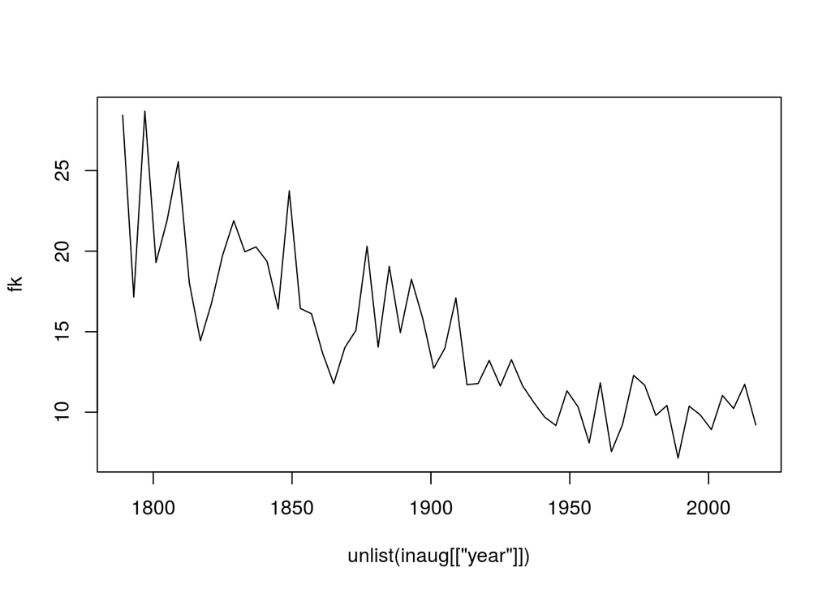

```r
# readability
fk <- textstat_readability(inaug, "Flesch.Kincaid")
plot(aggregate(fk ~ unlist(inaug[["year"]]), FUN=mean), type="l")
```

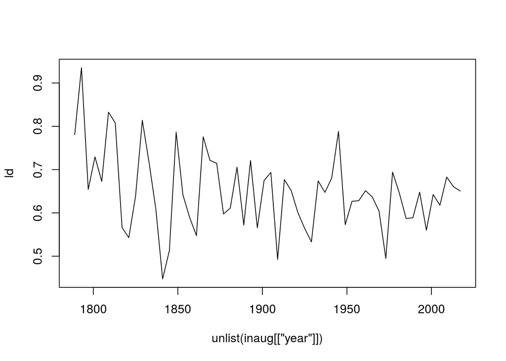

```r
# lexical diversity
ld <- textstat_lexdiv(inaugdfm, "TTR")
plot(aggregate(ld ~ unlist(inaug[["year"]]), FUN=mean), type="l")
```

### Identifying most unique features of documents

```r
rew <- tfidf(inaugdfm)
# now most frequent features are different
topfeatures(inaugdfm)
```

```
##     people government         us        can       upon       must
##        574        564        478        471        372        366
##      great        may     states      shall
##        340        338        333        314
```

```r
topfeatures(rew)
```

```
##      america        union constitution     congress      freedom
##     52.39413     51.14846     40.21661     39.13390     38.31822
##      revenue       public         laws       states      federal
##     34.11779     33.74429     33.57614     33.52316     32.83026
```

*Keyness* is a measure of to what extent some features are specific to a (group of) document in comparison to the rest of the corpus, taking into account that some features may be too rare.

```r
head(textstat_keyness(inaugdfm, target=docnames(inaugdfm)=="2017-Trump.txt",
                      measure="chi2"), n=20)
head(textstat_keyness(inaugdfm, target=docnames(inaugdfm)=="2017-Trump.txt",
                      measure="lr"), n=20)
head(textstat_keyness(inaugdfm, target=docnames(inaugdfm)=="2009-Obama.txt",
                      measure="chi2"), n=20)
head(textstat_keyness(inaugdfm, target=docnames(inaugdfm)=="2009-Obama.txt",
                      measure="lr"), n=20)
head(textstat_keyness(inaugdfm, target=docvars(inaugdfm)$year>1990,
                      measure="chi2"), n=20)
head(textstat_keyness(inaugdfm, target=docvars(inaugdfm)$year>1990,
                      measure="lr"), n=20)
```

We can use `textplot_xray` to visualize where some words appear in the corpus.

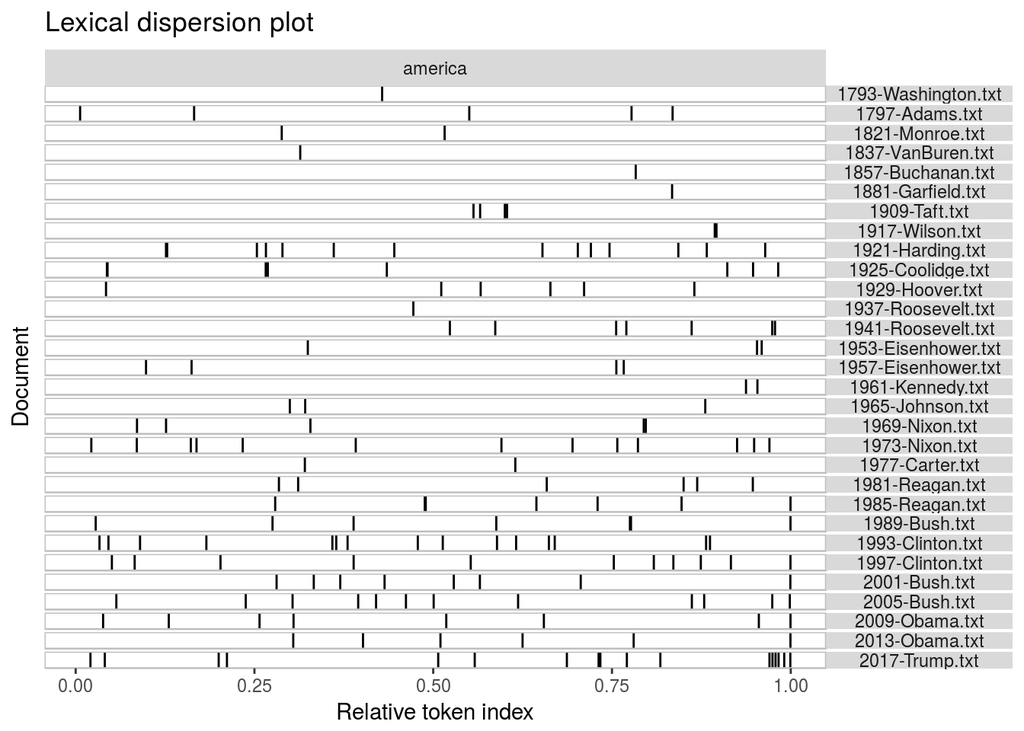

```r
textplot_xray(kwic(inaug, "america"))
```

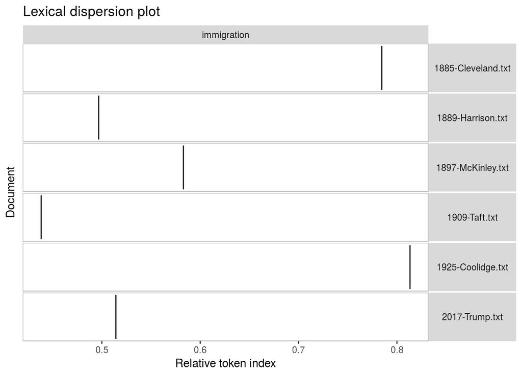

```r
textplot_xray(kwic(inaug, "immigration"))
```

### Clustering documents and features

We can identify documents that are similar to one another based on the frequency of words, using `similarity`. There’s different metrics to compute similarity. Here we explore two of them: [Jaccard distance](https://en.wikipedia.org/wiki/Jaccard_index) and [Cosine distance](https://en.wikipedia.org/wiki/Cosine_similarity).

```r
# document similarities
simils <- textstat_simil(inaugdfm, "2017-Trump.txt", margin="documents", method="jaccard")
# most similar documents
df <- data.frame(
  docname = rownames(simils),
  simil = as.numeric(simils),
  stringsAsFactors=F
)
tail(df[order(simils),])
```

```
##             docname     simil
## 47   1969-Nixon.txt 0.1558164
## 53 1993-Clinton.txt 0.1572104
## 58   2013-Obama.txt 0.1592292
## 54 1997-Clinton.txt 0.1748927
## 52    1989-Bush.txt 0.1792956
## 1    2017-Trump.txt 1.0000000
```

```r
head(df[order(simils),])
```

```
##                docname      simil
## 3  1793-Washington.txt 0.03585657
## 12    1829-Jackson.txt 0.06420927
## 8     1813-Madison.txt 0.07500000
## 21    1865-Lincoln.txt 0.08047690
## 4       1797-Adams.txt 0.08395522
## 15   1841-Harrison.txt 0.08429503
```

```r
# another example
simils <- textstat_simil(inaugdfm, "2013-Obama.txt", margin="documents", method="jaccard")
# most similar documents
df <- data.frame(
  docname = rownames(simils),
  simil = as.numeric(simils),
  stringsAsFactors=F
)
tail(df[order(simils),])
```

```
##             docname     simil
## 53 1993-Clinton.txt 0.1920398
## 56    2005-Bush.txt 0.1971067
## 54 1997-Clinton.txt 0.2010969
## 57   2009-Obama.txt 0.2058584
## 55    2001-Bush.txt 0.2069317
## 1    2013-Obama.txt 1.0000000
```

```r
head(df[order(simils),])
```

```
##                docname      simil
## 3  1793-Washington.txt 0.02781641
## 21    1865-Lincoln.txt 0.07639681
## 12    1829-Jackson.txt 0.08471276
## 2  1789-Washington.txt 0.08675799
## 8     1813-Madison.txt 0.08720930
## 17     1849-Taylor.txt 0.09290709
```

And the opposite: term similarity based on the frequency with which they appear in documents:

```r
# term similarities
simils <- textstat_simil(inaugdfm, "unemployment", margin="features", method="cosine")
# most similar features
df <- data.frame(
  featname = rownames(simils),
  simil = as.numeric(simils),
  stringsAsFactors=F
)
head(df[order(simils, decreasing=TRUE),], n=10)
```

```
##          featname     simil
## 1    unemployment 1.0000000
## 6968   inflations 1.0000000
## 6969    upheavals 1.0000000
## 6985      miracle 1.0000000
## 6918      lighten 0.8164966
## 6974       levels 0.8164966
## 7017        costs 0.8164966
## 6916       normal 0.7715167
## 6820       noting 0.7071068
## 6821   ruggedness 0.7071068
```

```r
# another example...
simils <- textstat_simil(inaugdfm, "immigration", margin="features", method="cosine")
# most similar features
df <- data.frame(
  featname = rownames(simils),
  simil = as.numeric(simils),
  stringsAsFactors=F
)
head(df[order(simils, decreasing=TRUE),], n=10)
```

```
##          featname     simil
## 1     immigration 1.0000000
## 473  expenditures 0.7092081
## 2817     taxation 0.7089176
## 5770   protective 0.7071068
## 5663       monroe 0.7071068
## 5325      methods 0.6940221
## 5849       courts 0.6900656
## 314        policy 0.6845266
## 2256      capital 0.6793662
## 2151  intelligent 0.6735753
```

Each of these can then be used to cluster documents:

```r
recent <- inaugdfm[46:58,]
# compute distances
distances <- textstat_dist(recent, margin="documents")
as.matrix(distances)[1:5, 1:5]
```

```
##                 1969-Nixon.txt 1973-Nixon.txt 1977-Carter.txt
## 1969-Nixon.txt         0.00000       56.06247        52.15362
## 1973-Nixon.txt        56.06247        0.00000        58.57474
## 1977-Carter.txt       52.15362       58.57474         0.00000
## 1981-Reagan.txt       57.79273       62.42596        52.91503
## 1985-Reagan.txt       58.42089       61.51423        60.09160
##                 1981-Reagan.txt 1985-Reagan.txt
## 1969-Nixon.txt         57.79273        58.42089
## 1973-Nixon.txt         62.42596        61.51423
## 1977-Carter.txt        52.91503        60.09160
## 1981-Reagan.txt         0.00000        52.35456
## 1985-Reagan.txt        52.35456         0.00000
```

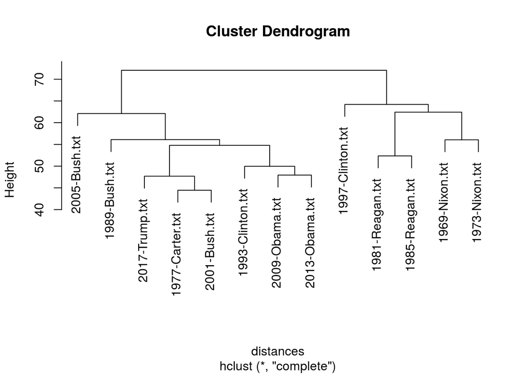

```r
# clustering
cluster <- hclust(distances)
plot(cluster)
```

A different type of clustering is [principal component analysis](https://en.wikipedia.org/wiki/Principal_component_analysis). This technique will try to identify a set of uncorrelated variables that capture most of the variance in the document-feature matrix. The first component will always capture the largest proportion of the variance; the second captures the second largest, etc. Looking at the relative proportion of the variance captured by the first component vs the rest, we can see to what extent we can reduce the dataset to just one dimension.

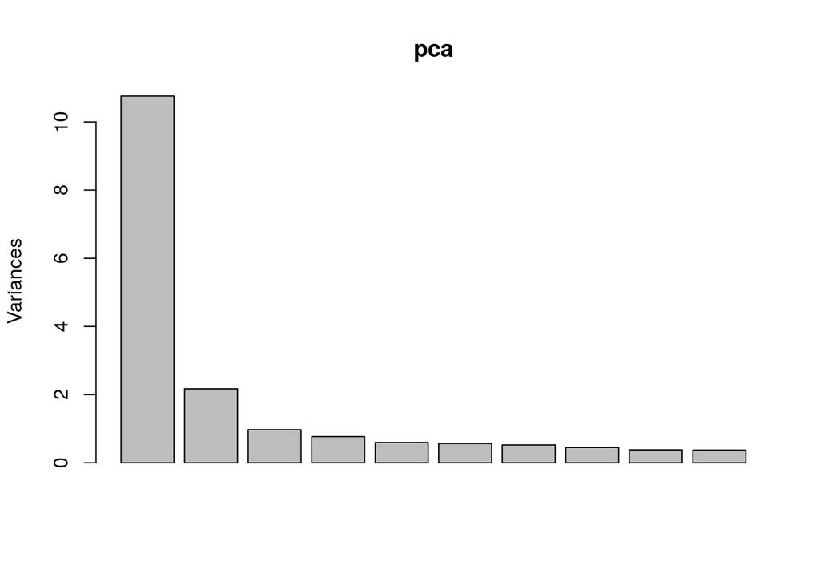

```r
# Principal components analysis
pca <- prcomp(t(as.matrix(inaugdfm)))
plot(pca) # first PC captures most of the variance
```

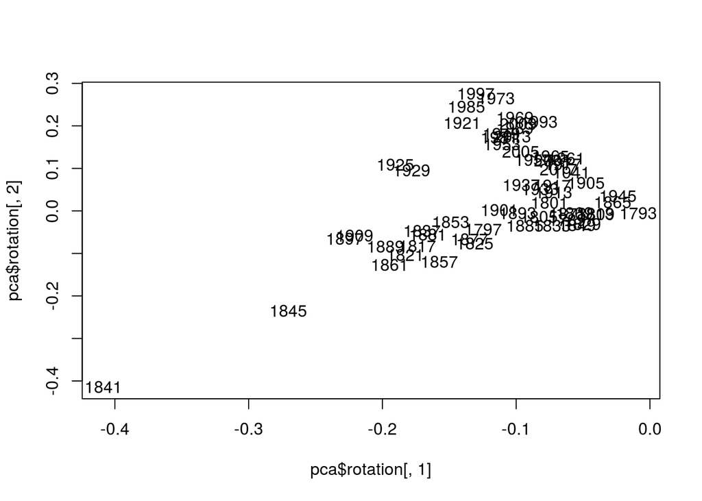

```r
# plot first principal component
plot(pca$rotation[,1], pca$rotation[,2], type="n")
text(pca$rotation[,1], pca$rotation[,2], labels=docvars(inaugdfm)$year)
```

```r
# looking at features for each PC
df <- data.frame(
  featname = featnames(inaugdfm),
  dim1 = pca$x[,1],
  dim2 = pca$x[,2],
  stringsAsFactors=FALSE
)

head(df[order(df$dim1),])
```

```
##              featname      dim1        dim2
## government government -91.99799 -17.7906574
## people         people -86.99912   0.1202627
## can               can -68.13781  13.8978189
## upon             upon -63.85890 -16.6942870
## states         states -58.80246 -27.4773302
## may               may -55.79016 -16.7111393
```

```r
tail(df[order(df$dim1),])
```

```
##                featname     dim1        dim2
## manger           manger 1.036135  0.00230314
## emerson         emerson 1.036135  0.00230314
## stout             stout 1.036135  0.00230314
## anguished     anguished 1.036135  0.00230314
## arrive           arrive 1.051498 -0.03782624
## upbraidings upbraidings 1.051498 -0.03782624
```

```r
head(df[order(df$dim2),])
```

```
##                  featname      dim1      dim2
## states             states -58.80246 -27.47733
## constitution constitution -40.00990 -26.34383
## power               power -43.46073 -17.97085
## government     government -91.99799 -17.79066
## union               union -32.00131 -17.00456
## may                   may -55.79016 -16.71114
```

```r
tail(df[order(df$dim2),])
```

```
##         featname      dim1     dim2
## let          let -15.09198 20.09348
## must        must -50.45240 23.71288
## america  america -19.14361 28.03991
## new          new -28.91197 30.88069
## world      world -35.69456 39.69114
## us            us -55.42587 47.55032
```

A similar dimensionality reduction technique is [correspondence analysis](https://en.wikipedia.org/wiki/Correspondence_analysis). We’ll see it with more detail when we get to networks, but note that the intuition and results are similar.

```r
out <- textmodel_ca(inaugdfm)

# documents
df <- data.frame(
  docname = docnames(inaugdfm),
  year = docvars(inaugdfm)$year,
  dim1 = out$rowcoord[,1],
  dim2 = out$rowcoord[,2],
  stringsAsFactors=FALSE
)

head(df[order(df$dim1),])
```

```
##                                 docname year       dim1      dim2
## 1829-Jackson.txt       1829-Jackson.txt 1829 -1.0990430 0.7381613
## 1821-Monroe.txt         1821-Monroe.txt 1821 -1.0517787 0.7720043
## 1841-Harrison.txt     1841-Harrison.txt 1841 -1.0022261 1.1756806
## 1845-Polk.txt             1845-Polk.txt 1845 -0.9939273 0.6262135
## 1789-Washington.txt 1789-Washington.txt 1789 -0.9644526 1.5125154
## 1809-Madison.txt       1809-Madison.txt 1809 -0.9341294 1.0908122
```

```r
tail(df[order(df$dim1),])
```

```
##                           docname year     dim1      dim2
## 2013-Obama.txt     2013-Obama.txt 2013 1.639522 0.8249100
## 1989-Bush.txt       1989-Bush.txt 1989 1.685719 0.5975886
## 1997-Clinton.txt 1997-Clinton.txt 1997 1.718777 0.6435507
## 2017-Trump.txt     2017-Trump.txt 2017 1.730728 1.0665831
## 1969-Nixon.txt     1969-Nixon.txt 1969 1.850393 0.5231348
## 1993-Clinton.txt 1993-Clinton.txt 1993 1.855148 0.7175599
```

```r
head(df[order(df$dim2),])
```

```
##                               docname year         dim1      dim2
## 1921-Harding.txt     1921-Harding.txt 1921  0.564002704 -2.803218
## 1909-Taft.txt           1909-Taft.txt 1909 -0.771896204 -2.023413
## 1913-Wilson.txt       1913-Wilson.txt 1913  0.719391719 -1.560413
## 1893-Cleveland.txt 1893-Cleveland.txt 1893 -0.592392860 -1.517012
## 1929-Hoover.txt       1929-Hoover.txt 1929 -0.008040453 -1.455221
## 1889-Harrison.txt   1889-Harrison.txt 1889 -0.684563134 -1.193699
```

```r
tail(df[order(df$dim2),])
```

```
##                                 docname year       dim1     dim2
## 2017-Trump.txt           2017-Trump.txt 2017  1.7307285 1.066583
## 2009-Obama.txt           2009-Obama.txt 2009  1.6270751 1.069058
## 1809-Madison.txt       1809-Madison.txt 1809 -0.9341294 1.090812
## 1841-Harrison.txt     1841-Harrison.txt 1841 -1.0022261 1.175681
## 1813-Madison.txt       1813-Madison.txt 1813 -0.7323702 1.194203
## 1789-Washington.txt 1789-Washington.txt 1789 -0.9644526 1.512515
```

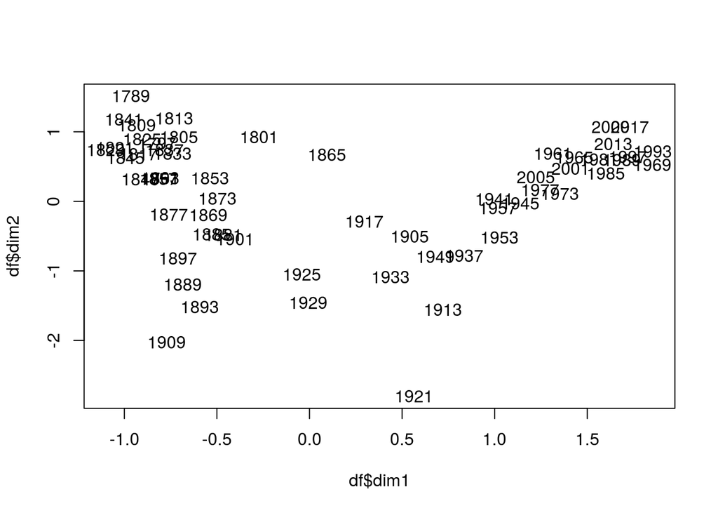

```r
plot(df$dim1, df$dim2, type="n")
text(df$dim1, df$dim2, labels=df$year)
```

```r
# features
df <- data.frame(
  featname = featnames(inaugdfm),
  dim1 = out$colcoord[,1],
  dim2 = out$colcoord[,2],
  stringsAsFactors=FALSE
)

head(df[order(df$dim1),])
```

```
##                  featname      dim1     dim2
## customary       customary -1.810611 1.500468
## convinces       convinces -1.810611 1.500468
## admonishes     admonishes -1.810611 1.500468
## superintend   superintend -1.810611 1.500468
## confederate   confederate -1.810611 1.500468
## transcending transcending -1.810611 1.500468
```

```r
tail(df[order(df$dim1),])
```

```
##                featname     dim1     dim2
## myriad           myriad 3.056251 1.458591
## well-doing   well-doing 3.056251 1.458591
## reap               reap 3.056251 1.458591
## faint             faint 3.056251 1.458591
## joyful           joyful 3.056251 1.458591
## mountaintop mountaintop 3.056251 1.458591
```

```r
head(df[order(df$dim2),])
```

```
##                    featname      dim1     dim2
## new-world         new-world 0.9291623 -5.69813
## materially       materially 0.9291623 -5.69813
## spiritually     spiritually 0.9291623 -5.69813
## crave                 crave 0.9291623 -5.69813
## unselfishness unselfishness 0.9291623 -5.69813
## dependable       dependable 0.9291623 -5.69813
```

```r
tail(df[order(df$dim2),])
```

```
##                    featname      dim1     dim2
## renounce           renounce -1.588881 3.074506
## inapplicable   inapplicable -1.588881 3.074506
## emoluments       emoluments -1.588881 3.074506
## indispensably indispensably -1.588881 3.074506
## supplication   supplication -1.588881 3.074506
## deliberating   deliberating -1.588881 3.074506
```